# LIDAR antenna constraint — marjum-2026-07

A viewing interface for the platform-LIDAR constraint on the antenna position. It caches nothing: the returns come from the campaign pointing table, the antenna prior from the campaign's published geometry release, the DEM and the fitted result from the `terrain/` checkout, and the ray march is `marjum_lidar_constraint.march` itself rather than a copy. Pointing it at a different release or a different fit is an edit to section 1 only.

Sections 3 and 4 are static, slide-ready figures at the published fit. Section 5 is the interactive explorer: every free parameter in the fit is exposed, including the ones the memo held fixed.

### What this is for

Two claims in the memo are worth pushing on by hand rather than taking on faith:

1. **The east/north position.** The memo held `dE`/`dN` at the photogrammetric value; letting them move absorbs some of the second-dip mismatch but does not reproduce across data subsets. The sliders show the trade directly — in particular how `daz` and `dN` swap against each other.
2. **The DEM-error hypothesis.** The memo argues the residual second-dip depth is terrain-model error, because a rigid translation can displace a dip but not deepen one. The `DEM bias` slider lets you try to fix it that way and see what it costs elsewhere.

### Replaces the cached version

Until 2026-09-21 this notebook read a 0.3 MB `lidar_explorer_cache.npz` holding a DEM subtile and a copy of the returns, and re-implemented the ray march in numpy. The cache never shipped beside the notebook, so the notebook did not run here at all; the reimplementation was a second definition of the model that could drift from the memo. Both are gone. The DEM loads in ~0.5 s and a full march takes milliseconds, so the cache bought nothing.

## 1. Inputs

Everything below is read at run time. Nothing is a literal that a new geometry release or a re-run fit would leave stale.

```python
from pathlib import Path
import json
import os
import sys

import numpy as np
import matplotlib.pyplot as plt
import ipywidgets as W
from IPython.display import display

PLOT_BACKEND = os.environ.get('EIGSEP_NOTEBOOK_BACKEND', 'widget')
get_ipython().run_line_magic('matplotlib', PLOT_BACKEND)

ROOT = next(p for p in [Path.cwd(), *Path.cwd().parents]
            if (p / 'marjum-2026-07/data').is_dir()
            and (p / 'marjum-2026-07/imgs/fits').is_dir())
CAMPAIGN = ROOT / 'marjum-2026-07'

# The DEM and the fitted LIDAR constraint live in the terrain checkout, which is
# scoped to terrain fitting and is not an installable package. Resolve it the
# way eigsep_data.geometry_release does -- EIGSEP_TERRAIN_ROOT, else beside the
# campaign -- rather than assuming a working directory.
TERRAIN = Path(os.environ.get('EIGSEP_TERRAIN_ROOT', ROOT / 'terrain'))
if not (TERRAIN / 'marjum_lidar_constraint.py').exists():
    raise SystemExit(f'terrain checkout not found at {TERRAIN}; set EIGSEP_TERRAIN_ROOT')
if str(TERRAIN) not in sys.path:
    sys.path.insert(0, str(TERRAIN))

import eigsep_data
from eigsep_terrain.marjum_dem import MarjumDEM
import marjum_lidar_constraint as M

eigsep_data.set_campaign_root(CAMPAIGN)

print('Campaign :', CAMPAIGN)
print('Terrain  :', TERRAIN)
print('Pointing :', M.POINTING)

# ---------------------------------------------------------------- talk style
# One place to set figure appearance. TALK=True gives slide-legible type and
# line weights; TALK=False returns to compact notebook defaults. Figures are
# written to FIGDIR as PNG (raster, for slides) and PDF (vector, for print)
# whenever SAVE_FIGURES is set.
TALK = True
SAVE_FIGURES = False
# 'linear' shows the shape of the dips; 'log' compresses the 30-200 m span.
RANGE_YSCALE = 'linear'
# Shade and label the W1/W2/W3 scoring bins on the range profile. Off for the
# talk figures -- the bins are a scoring device, and on a slide they read as a
# feature of the terrain. The explorer turns them back on, where the scorecard
# quotes a median per bin and the shading says which is which.
SHOW_WINDOWS = False
FIGDIR = Path('figures')

plt.rcParams.update({
    'figure.dpi': 110,
    'savefig.dpi': 220,
    'savefig.bbox': 'tight',
    'font.size': 15 if TALK else 10,
    'axes.titlesize': 17 if TALK else 11,
    'axes.labelsize': 15 if TALK else 10,
    'axes.titleweight': 'semibold',
    'axes.labelpad': 6,
    'xtick.labelsize': 13 if TALK else 9,
    'ytick.labelsize': 13 if TALK else 9,
    'legend.fontsize': 13 if TALK else 9,
    'legend.frameon': False,
    'lines.linewidth': 2.2 if TALK else 1.2,
    'axes.spines.top': False,
    'axes.spines.right': False,
    'image.interpolation': 'nearest',
    'figure.facecolor': 'white',
})


def save(fig, name):
    """Write `fig` to FIGDIR/name.{png,pdf} when SAVE_FIGURES is set."""
    if not SAVE_FIGURES:
        return
    FIGDIR.mkdir(exist_ok=True)
    for ext in ('png', 'pdf'):
        fig.savefig(FIGDIR / f'{name}.{ext}')
    print('wrote', FIGDIR / f'{name}.png')
```

```
Campaign : /home/aparsons/projects/global21cm/eigsep/marjum-2026-07
Terrain  : /home/aparsons/projects/global21cm/eigsep/terrain
Pointing : /home/aparsons/projects/global21cm/eigsep/marjum-2026-07/pointing/pointing_table_v0.npz
```

```python
# --- LIDAR returns, straight from the campaign pointing table ----------------
RET = M.load_returns()
EL, AZ, D, T = RET['el'], RET['az'], RET['d'], RET['t']
DWELL, SWEEP = RET['plateau'], RET['sweep']
NEARF, PLUMB = RET['nearfield'], RET['plumb']
TMIN = T.min()

# --- antenna prior, from the campaign's published geometry release -----------
# Not a literal: the release is the authority, and reading it here means a new
# release changes this notebook's prior without an edit.
RELEASES = sorted((CAMPAIGN / 'imgs/fits').glob('v[0-9][0-9][0-9][0-9]_marjum_geometry'))
RELEASE = RELEASES[-1]
SHARED = json.loads((RELEASE / 'shared.json').read_text())
ANT = np.asarray(SHARED['antenna_91m_era']['position_enu_m'], float)

# --- DEM, from the terrain checkout ------------------------------------------
# marjum_dem_sw.npz carries its own e0_px/n0_px working-grid anchor, so
# MarjumDEM lands in working-grid coordinates unaided. Do NOT wrap it in
# marjum_bundle.working_grid: that predates the anchor and shifts twice.
DEM = MarjumDEM(cache_file=str(TERRAIN / 'marjum_dem_sw.npz'))

# --- the published fit this notebook exists to interrogate -------------------
SUMMARY = json.loads((TERRAIN / 'lidar_constraint_v2/summary.json').read_text())
PUB = SUMMARY['by_el_nadir']['plumb']['best_fit']
PLUMBFIT = {k: v for k, v in SUMMARY['plumb'].items() if not k.startswith('profile')}
ENCFG = SUMMARY['en_exploration']['configs']
WIN = SUMMARY['en_exploration']['window_definitions']

print('geometry release   :', RELEASE.name, SHARED['antenna_91m_era']['status'])
print('antenna prior (ENU):', np.round(ANT, 3), '  module literal:', M.ANTENNA)
print('DEM                : %s @ %.2f m, e0_px=%d n0_px=%d'
      % (DEM.data.shape, DEM.res, DEM.e0_px, DEM.n0_px))
print('returns %d -> dwell %d | sweep %d | near-field %d (plumb cluster %d)'
      % (len(EL), DWELL.sum(), SWEEP.sum(), NEARF.sum(), PLUMB.sum()))
print('published fit      :', PUB)
print('plumb fit          :', {k: (round(v, 3) if isinstance(v, float) else v)
                               for k, v in PLUMBFIT.items()})

# --- self-check: reproduce the published numbers from these live inputs ------
_o = ANT + np.array([0., 0., PUB['dU_m']])
_p = M.march(DEM, _o, EL[SWEEP], AZ[SWEEP] + PUB['daz_deg'], PUB['el_nadir_deg'])
_r = D[SWEEP] - _p
_shape = (D[SWEEP] > 80) & (D[SWEEP] < 130)
_ref = ENCFG['published']
print('\nself-check at the published fit (live DEM + live pointing table):')
print('  rays hitting terrain %d / %d' % (np.isfinite(_p).sum(), SWEEP.sum()))
print('  shape-set MAD %.4f m   (summary: %.4f)'
      % (np.nanmedian(np.abs(_r[_shape])), _ref['MAD']))
for _k, (_a, _b) in WIN.items():
    _m = _shape & (EL[SWEEP] >= _a) & (EL[SWEEP] < _b)
    print('  %s median   %+.4f m   (summary: %+.4f)'
          % (_k, np.nanmedian(_r[_m]), _ref[_k]))
```

```
geometry release   : v0001_marjum_geometry provisional deterministic fit
antenna prior (ENU): [1655.868 2030.923 1777.397]   module literal: [1655.868 2030.923 1777.397]
DEM                : (10000, 8000) @ 0.50 m, e0_px=2000 n0_px=2000
returns 665 -> dwell 488 | sweep 151 | near-field 26 (plumb cluster 14)
published fit      : {'daz_deg': 43.0, 'dU_m': 0.75, 'mad_m': 1.2600021360000113, 'el_nadir_deg': 92.25}
plumb fit          : {'n': 14, 'el_vertical_deg': -87.75, 'offset_x_m': 0.292, 'rms_resid_m': 0.057, 'el_nadir_deg': 92.25, 'el_nadir_lo': 91.0, 'el_nadir_hi': 93.75, 'rms_at_dwell_assumption': 0.095}

self-check at the published fit (live DEM + live pointing table):
  rays hitting terrain 147 / 151
  shape-set MAD 1.0300 m   (summary: 1.0300)
  W1 median   +1.0700 m   (summary: +1.0700)
  W2 median   -6.4350 m   (summary: -6.4350)
  W3 median   +0.9267 m   (summary: +0.9267)
```

## 2. The model

Two independent pieces of geometry, both exposed below.

**The terrain ray march.** The LIDAR sits at 90° to the antenna boresight, so only the LIDAR arm matters here — a LIDAR ground return is *not* evidence that the antenna pointed at the ground. The ray's zenith angle is `el − el_nadir + 180` and its azimuth is `az + daz`. March it from the antenna position in 0.5 m increments and take the first cell at or below the ray.

**The plumb line.** The near-field returns are the LIDAR striking the PVC frame carrying the antenna box. The frame hangs under gravity, so a ray at angle `chi` to it strikes it at `x / sin(chi)`. That is what measures `el_nadir` — and the link checkbox ties the two panels together, so moving the plumb line moves the terrain model too. That coupling *is* the memo's §4 result; watch what a degree does.

Note `x/sin(chi)` and `h/cos(chi−90)` are the same function, so this fit cannot distinguish a vertical line from a plane perpendicular to it. It measures the direction, not the shape.

```python
def march(origin, el, az_pot, el_nadir, bias=0.0):
    """Ranges from `marjum_lidar_constraint.march`, with an optional DEM bias.

    `bias` raises or lowers the whole terrain; it is the blunt instrument the
    memo's DEM-error hypothesis is tested with. It is applied by lowering the
    ray origin instead of copying the 320 MB DEM, which is equivalent for a
    first-intersection search and costs nothing.
    """
    o = np.asarray(origin, float) - np.array([0.0, 0.0, bias])
    return M.march(DEM, o, el, az_pot, el_nadir)


def ground_points(origin, el, az_pot, el_nadir, bias=0.0):
    """Where each ray meets the DEM (ENU, m). Undoes the `bias` origin shift
    so the returned points are in true coordinates rather than shifted ones."""
    o = np.asarray(origin, float) - np.array([0.0, 0.0, bias])
    points, _ = M.ground_points(DEM, o, el, az_pot, el_nadir)
    return points + np.array([0.0, 0.0, bias])


def plumb_model(el, x, el_vertical):
    """Range to a vertical member at perpendicular offset `x`."""
    return x / np.abs(np.sin(np.radians(el - el_vertical)))


def hillshade(z, res, az_deg=315.0, alt_deg=45.0):
    gy, gx = np.gradient(z, res, res)
    slope = np.pi / 2.0 - np.arctan(np.hypot(gx, gy))
    aspect = np.arctan2(-gx, gy)
    az, al = np.radians(360.0 - az_deg + 90.0), np.radians(alt_deg)
    v = (np.sin(al) * np.sin(slope)
         + np.cos(al) * np.cos(slope) * np.cos(az - aspect))
    return np.clip(v, 0, 1)


# Hillshade only the neighbourhood the rays can reach, at half resolution: the
# full 10000x8000 DEM takes ~10 s to shade and nothing outside RMAX is visible.
PAD_M = M.RMAX + 40.0
_c0 = int(round((ANT[0] - PAD_M) / DEM.res)) + DEM.e0_px
_c1 = int(round((ANT[0] + PAD_M) / DEM.res)) + DEM.e0_px
_r0 = int(round((ANT[1] - PAD_M) / DEM.res)) + DEM.n0_px
_r1 = int(round((ANT[1] + PAD_M) / DEM.res)) + DEM.n0_px
_sub = DEM.data[_r0:_r1:2, _c0:_c1:2].astype(np.float64)
# The DEM is int32, so elevation is quantised to 1 m and a raw gradient turns
# every quantisation step into speckle. A 3-pixel box smooth before shading
# removes it. This affects the backdrop only -- the ray march uses DEM.data.
_k = np.ones((3, 3)) / 9.0
_pad = np.pad(_sub, 1, mode='edge')
_smooth = sum(_k[i, j] * _pad[i:i + _sub.shape[0], j:j + _sub.shape[1]]
              for i in range(3) for j in range(3))
HS = hillshade(_smooth, DEM.res * 2)
HS_EXTENT = ((_c0 - DEM.e0_px) * DEM.res, (_c1 - DEM.e0_px) * DEM.res,
             (_r0 - DEM.n0_px) * DEM.res, (_r1 - DEM.n0_px) * DEM.res)
print('hillshade %s over E %.0f..%.0f  N %.0f..%.0f'
      % (HS.shape, *HS_EXTENT))


def masks(nf_cut, lo, hi):
    near = D < nf_cut
    dwell = DWELL & ~near
    sweep = SWEEP & ~near
    return near, dwell, sweep, sweep & (D > lo) & (D < hi)


def evaluate(p):
    """Predicted ranges, residuals and the memo's scalar diagnostics."""
    near, dwell, sweep, score = masks(p['nf'], p['lo'], p['hi'])
    origin = ANT + np.array([p['dE'], p['dN'], p['dU']])
    sel = sweep | dwell
    pred = np.full(len(EL), np.nan)
    pred[sel] = march(origin, EL[sel], AZ[sel] + p['daz'], p['eln'], bias=p['bias'])
    resid = D - pred
    out = dict(pred=pred, resid=resid, near=near, dwell=dwell, sweep=sweep,
               score=score, origin=origin)
    out['nhit'] = int(np.isfinite(pred[sweep]).sum())
    out['mad'] = float(np.nanmedian(np.abs(resid[score]))) if score.sum() else np.nan
    for name, (a, b) in WIN.items():
        m = score & (EL >= a) & (EL < b)
        out[name] = float(np.nanmedian(resid[m])) if m.sum() else np.nan
    out['dwell_med'] = float(np.nanmedian(resid[dwell])) if dwell.sum() else np.nan
    return out


print('model helpers ready')
```

```
hillshade (590, 590) over E 1361..1951  N 1736..2326
model helpers ready
```

```python
POP_COLOR = {'sweep': 'tab:blue', 'dwell': 'tab:orange', 'near': 'tab:red'}
POP_LABEL = {'sweep': 'sweep (canyon walls)', 'dwell': 'dwell (near-nadir)',
             'near': 'near-field (support frame)'}


def _ordered(mask, xaxis):
    """x, and a NaN-break mask for the gaps that would otherwise be drawn."""
    x = EL[mask] if xaxis == 'el' else (T[mask] - TMIN) / 60.0
    order = np.argsort(x)
    xs = x[order]
    # Break the connecting line across large x gaps; otherwise the two
    # near-field clusters (el ~ -103 and ~ +74) are joined by a line straight
    # across the plot, which reads as data.
    gap = np.r_[False, np.diff(xs) > (5.0 if xaxis == 'el' else 1.0)]
    return order, xs, gap


def draw_profile(R, p, ax_range, ax_resid, populations=('sweep',), xaxis='el',
                 windows=SHOW_WINDOWS, yscale=RANGE_YSCALE):
    """The range profile and its residual, shared by the figures and the explorer."""
    if windows and xaxis == 'el':
        for name, shade in (('W1', '0.93'), ('W2', '0.84'), ('W3', '0.93')):
            for axis in (ax_range, ax_resid):
                axis.axvspan(*WIN[name], color=shade, zorder=0)
            ax_range.annotate('%s\n%g\u2013%g\u00b0' % (name, *WIN[name]),
                              xy=(np.mean(WIN[name]), 1.005),
                              xycoords=('data', 'axes fraction'), ha='center',
                              va='bottom', fontsize=11, color='0.35',
                              linespacing=1.15)
    for name in populations:
        mask = {'sweep': R['sweep'], 'dwell': R['dwell'], 'near': R['near']}[name]
        if not mask.sum():
            continue
        order, xs, gap = _ordered(mask, xaxis)

        def brk(values):
            out = np.asarray(values, float).copy()
            out[gap] = np.nan
            return out

        ax_range.plot(xs, brk(D[mask][order]), 'o-', ms=5, lw=1.0,
                      color=POP_COLOR[name], label=POP_LABEL[name] + ', measured')
        if name != 'near':
            ax_range.plot(xs, brk(R['pred'][mask][order]), 'x--', ms=5, lw=1.0,
                          color='0.25', label=POP_LABEL[name] + ', DEM model')
            ax_resid.plot(xs, brk(R['resid'][mask][order]), 'o-', ms=4, lw=1.0,
                          color=POP_COLOR[name])
    ax_resid.axhline(0, color='0.55', lw=1.0)
    ax_range.set_yscale(yscale)
    ax_range.set_ylabel('Range [m]')
    if yscale == 'linear':
        # Clip to the terrain returns. A few sweep samples reach 200 m with no
        # model; on a linear axis they flatten the dips this figure is about.
        modelled = np.isfinite(R['pred'])
        if modelled.any():
            hi = np.nanmax(np.r_[D[modelled], R['pred'][modelled]])
            lo = np.nanmin(np.r_[D[modelled], R['pred'][modelled]])
            ax_range.set_ylim(max(0.0, lo - 0.08 * (hi - lo)), hi + 0.08 * (hi - lo))
    ax_range.legend(loc='upper left', ncol=2, fontsize=12)
    ax_resid.set_ylabel('Measured − model [m]')
    ax_resid.set_ylim(-20, 20)
    ax_resid.set_xlabel('Platform elevation [deg]' if xaxis == 'el'
                        else 'Minutes from first return')
    # Confine x to where the march produced a model. A handful of sweep returns
    # sit near el -100 with no terrain intersection; left in, they stretch the
    # axis until the 30-150 deg profile this figure is about is unreadable.
    modelled = np.isfinite(R['pred'])
    if modelled.any():
        x = EL[modelled] if xaxis == 'el' else (T[modelled] - TMIN) / 60.0
        pad = 0.04 * (x.max() - x.min())
        # Both axes: the static figure builds them with add_subplot, not sharex.
        for axis in (ax_range, ax_resid):
            axis.set_xlim(x.min() - pad, x.max() + pad)


def draw_plumb(p, ax):
    """The near-field, up-looking cluster against the hanging-frame model."""
    mask = NEARF & (EL < -90)
    el, rng = EL[mask], D[mask]
    grid = np.linspace(el.min() - 1.5, el.max() + 1.5, 300)
    ax.plot(el, rng, 'o', ms=7, color='tab:red', label='near-field, up-looking')
    ax.plot(grid, plumb_model(grid, p['px'], p['pel']), '-', color='0.2', lw=2.0,
            label='plumb: x=%.3f m, vertical at el=%.2f°' % (p['px'], p['pel']))
    rms = float(np.sqrt(np.mean((plumb_model(el, p['px'], p['pel']) - rng) ** 2)))
    ax.set_ylim(0, max(3.0, rng.max() * 1.6))
    ax.set_xlabel('Platform elevation [deg]')
    ax.set_ylabel('Range [m]')
    ax.legend(loc='upper right', fontsize=12)
    return rms


def draw_map(R, p, ax, fig):
    """Ray footprint on the hillshade, coloured by |residual|."""
    ax.imshow(HS, cmap='gray', origin='lower', extent=HS_EXTENT, zorder=0)
    mask = R['sweep']
    pts = ground_points(R['origin'], EL[mask], AZ[mask] + p['daz'], p['eln'],
                        bias=p['bias'])
    good = np.isfinite(pts[:, 0])
    points = ax.scatter(pts[good, 0], pts[good, 1],
                        c=np.clip(np.abs(R['resid'][mask][good]), 0, 20),
                        s=34, cmap='autumn_r', edgecolors='k', linewidths=0.3,
                        zorder=3)
    fig.colorbar(points, ax=ax, label='|residual| [m]', shrink=0.85, pad=0.02)
    ax.plot(*ANT[:2], 'c+', ms=14, mew=3, zorder=4, label='photogrammetric prior')
    ax.plot(*R['origin'][:2], 'b*', ms=18, mec='k', zorder=5, label='tuned position')
    ax.set_xlim(min(np.nanmin(pts[good, 0]), ANT[0]) - 40,
                max(np.nanmax(pts[good, 0]), ANT[0]) + 40)
    ax.set_ylim(min(np.nanmin(pts[good, 1]), ANT[1]) - 40,
                max(np.nanmax(pts[good, 1]), ANT[1]) + 40)
    ax.set_aspect('equal')
    ax.set_xlabel('East [m]')
    ax.set_ylabel('North [m]')
    ax.legend(loc='upper left', fontsize=12, frameon=True, framealpha=0.85,
              facecolor='white', edgecolor='none')


def scorecard(R):
    """The memo's diagnostics, with the published value beside each."""
    ref = ENCFG['published']
    lines = ['rays hitting terrain %d / %d      scored %d'
             % (R['nhit'], int(R['sweep'].sum()), int(R['score'].sum())),
             'shape MAD   %7.3f m   (published %+.3f)' % (R['mad'], ref['MAD'])]
    for name in ('W1', 'W2', 'W3'):
        note = '   <-- the second dip' if name == 'W2' else ''
        lines.append('%s median   %+7.3f m   (published %+.3f)  el %g-%g%s'
                     % (name, R[name], ref[name], *WIN[name], note))
    lines.append('dwell median residual %+.3f m' % R['dwell_med'])
    return '\n'.join(lines)


PUBLISHED = dict(daz=PUB['daz_deg'], eln=PUB['el_nadir_deg'], dU=PUB['dU_m'],
                 dE=0.0, dN=0.0, bias=0.0, nf=M.NEARFIELD_MAX, lo=80.0, hi=130.0,
                 px=PLUMBFIT['offset_x_m'], pel=PLUMBFIT['el_vertical_deg'])
print('figure helpers ready')
```

```
figure helpers ready
```

## 3. Range profile at the published fit

**W1, W2, W3** are not named features. They are three contiguous elevation bins covering the upper half of the sweep — W1 88–105°, W2 105–122°, W3 122–140° — and the fit is scored by the *median residual in each one separately* rather than by one number over the whole sweep. The reason is that the two failure modes they separate look identical in a single MAD:

- a **position error** displaces the whole profile, so W1, W2 and W3 all move the same way together;
- a **terrain-model error** distorts it, so they move independently.

W2 is the bin holding the second dip, and it is the one that does not come out: it sits at −6.4 m while W1 and W3 are within ±1.1 m. That asymmetry is the memo's evidence for DEM error over a mis-placed antenna — and it is what the explorer in section 5 is for.

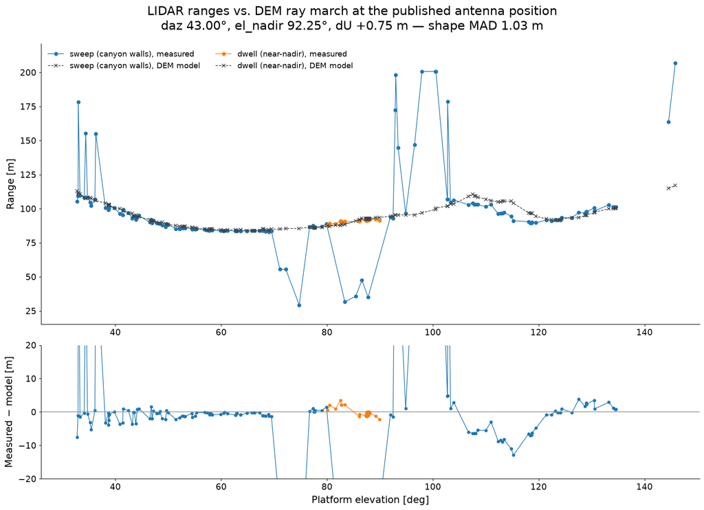

```
rays hitting terrain 147 / 151      scored 127
shape MAD     1.030 m   (published +1.030)
W1 median    +1.070 m   (published +1.070)  el 88-105
W2 median    -6.435 m   (published -6.435)  el 105-122   <-- the second dip
W3 median    +0.927 m   (published +0.927)  el 122-140
dwell median residual -0.182 m
```

```python
R_pub = evaluate(PUBLISHED)

fig = plt.figure(figsize=(15, 10), constrained_layout=True)
gs = fig.add_gridspec(2, 1, height_ratios=[2.1, 1])
ax_range, ax_resid = fig.add_subplot(gs[0]), fig.add_subplot(gs[1])
draw_profile(R_pub, PUBLISHED, ax_range, ax_resid, populations=('sweep', 'dwell'))
fig.suptitle('LIDAR ranges vs. DEM ray march at the published antenna position\n'
             'daz %.2f°, el_nadir %.2f°, dU %+.2f m — shape MAD %.2f m'
             % (PUBLISHED['daz'], PUBLISHED['eln'], PUBLISHED['dU'], R_pub['mad']),
             fontsize=19, y=1.08)
save(fig, 'lidar_profile_published')
plt.show()
print(scorecard(R_pub))
```

## 4. Where the rays land, and the plumb line that sets `el_nadir`

[output not shown]

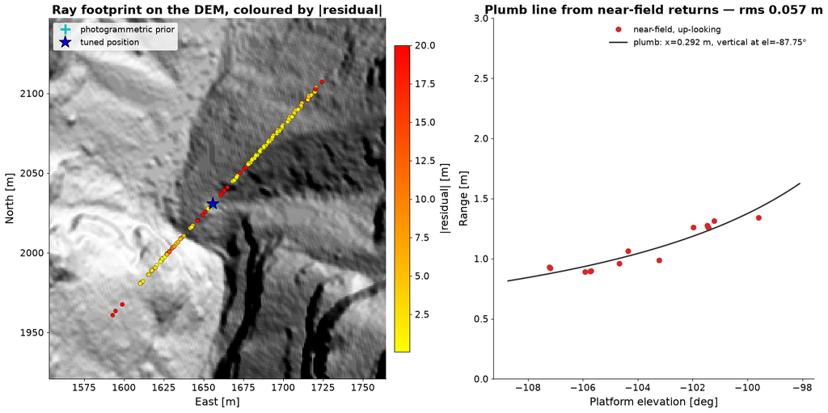

```python
fig, (ax_map, ax_plumb) = plt.subplots(
    1, 2, figsize=(17, 8), constrained_layout=True,
    gridspec_kw=dict(width_ratios=[1.35, 1]))
draw_map(R_pub, PUBLISHED, ax_map, fig)
ax_map.set_title('Ray footprint on the DEM, coloured by |residual|')
rms = draw_plumb(PUBLISHED, ax_plumb)
ax_plumb.set_title('Plumb line from near-field returns — rms %.3f m' % rms)
save(fig, 'lidar_footprint_and_plumb')
plt.show()
```

## 5. Interactive explorer

**Tips for exploring by hand**

- **`el_nadir` is the dominant knob.** It moves the fit about 1 m of apparent antenna height per degree, and it is what changed the memo's answer between revisions 1 and 2. The plumb line measures it as 92.25° ± 1.4°; revision 1 assumed 87.68°. Try both.
- **Watch `daz` and `dN` trade.** Push `dN` to −6 and re-snap `daz`: it drops from ~43° to ~36°. That coupling is why the azimuth registration cannot be quoted tighter than ~36–47° once E/N is free.
- **Score on the shape set** (measured range 80–130 m). That window is chosen from the *measured* values alone, so it cannot favour a model. The W2 readout is the second dip — the feature under discussion.
- **`DEM bias` shifts the whole terrain up or down.** Deliberately a blunt instrument: if the second-dip mismatch were a simple terrain offset this would fix it. Watch what it does to W1 and W3 while you try.
- **`snap daz/dU`** grid-searches azimuth and height at your current E/N and `el_nadir`. Use it after moving E/N so you compare best-achievable against best-achievable rather than against a stale azimuth.
- **Near-field samples are excluded** from scoring by the `near-field cut`; they are the support frame, not terrain. Drop the cut to 0 to see what including them does.

The sliders need a live kernel with `ipywidgets`. In a rendered HTML or PDF copy this section shows its last executed state; sections 3 and 4 are the figures meant to be read statically.

```python
def _fs(desc, val, lo, hi, st, fmt='.2f'):
    return W.FloatSlider(value=val, min=lo, max=hi, step=st, description=desc,
                         continuous_update=False, readout_format=fmt,
                         style={'description_width': '140px'},
                         layout=W.Layout(width='430px'))


daz_w = _fs('daz (deg)', PUBLISHED['daz'], 0.0, 90.0, 0.25)
eln_w = _fs('el_nadir (deg)', PUBLISHED['eln'], 80.0, 100.0, 0.05)
dU_w = _fs('antenna dU (m)', PUBLISHED['dU'], -10.0, 10.0, 0.05)
dE_w = _fs('antenna dE (m)', 0.0, -20.0, 20.0, 0.25)
dN_w = _fs('antenna dN (m)', 0.0, -20.0, 20.0, 0.25)
bias_w = _fs('DEM bias (m)', 0.0, -15.0, 15.0, 0.25)

px_w = _fs('plumb x (m)', PUBLISHED['px'], 0.02, 1.00, 0.005, '.3f')
link_w = W.Checkbox(value=True, description='link plumb to el_nadir',
                    indent=False, layout=W.Layout(width='270px'))
pel_w = _fs('plumb el_vertical', PUBLISHED['pel'], -100.0, -76.0, 0.05)

nf_w = _fs('near-field cut (m)', M.NEARFIELD_MAX, 0.0, 40.0, 1.0, '.0f')
lo_w = _fs('score range lo (m)', 80.0, 0.0, 200.0, 5.0, '.0f')
hi_w = _fs('score range hi (m)', 130.0, 10.0, 260.0, 5.0, '.0f')
xaxis_w = W.Dropdown(options=[('elevation', 'el'), ('time', 't')], value='el',
                     description='x axis', style={'description_width': '140px'},
                     layout=W.Layout(width='330px'))
pop_w = W.SelectMultiple(options=[('sweep', 'sweep'), ('dwell', 'dwell'),
                                  ('near-field', 'near')],
                         value=('sweep',), description='show',
                         style={'description_width': '140px'},
                         layout=W.Layout(width='330px', height='80px'))
map_w = W.Checkbox(value=False, description='show map panel (slower)', indent=False,
                   layout=W.Layout(width='270px'))
plumb_w = W.Checkbox(value=True, description='show plumb panel', indent=False,
                     layout=W.Layout(width='270px'))

snap_b = W.Button(description='snap daz/dU', button_style='info',
                  tooltip='grid-search daz and dU at the current E/N and el_nadir')
pub_b = W.Button(description='reset: published')
rev1_b = W.Button(description='reset: revision 1')
en_b = W.Button(description='reset: E/N refit')

out = W.Output()
_busy = {'on': False}


def params():
    eln = eln_w.value
    return dict(daz=daz_w.value, eln=eln, dU=dU_w.value, dE=dE_w.value,
                dN=dN_w.value, bias=bias_w.value, nf=nf_w.value,
                lo=lo_w.value, hi=hi_w.value, px=px_w.value,
                pel=(eln - 180.0) if link_w.value else pel_w.value)


def redraw(*_):
    if _busy['on']:
        return
    p = params()
    R = evaluate(p)
    with out:
        out.clear_output(wait=True)
        nrow = 2 + int(plumb_w.value)
        fig = plt.figure(figsize=(13, 5.4 + 3.2 * (nrow - 2)))
        gs = fig.add_gridspec(nrow, 1, height_ratios=[2, 1] + [1.6] * (nrow - 2),
                              hspace=0.55)
        ax_range, ax_resid = fig.add_subplot(gs[0]), fig.add_subplot(gs[1])
        draw_profile(R, p, ax_range, ax_resid, populations=pop_w.value,
                     xaxis=xaxis_w.value, windows=True)
        ax_range.set_title('daz %.2f | el_nadir %.2f | dE %+.2f dN %+.2f dU %+.2f '
                           '| DEM bias %+.2f'
                           % (p['daz'], p['eln'], p['dE'], p['dN'], p['dU'], p['bias']),
                           fontsize=14)
        if plumb_w.value:
            rms = draw_plumb(p, fig.add_subplot(gs[2]))
            print('plumb rms %.3f m   (published %.3f)' % (rms, PLUMBFIT['rms_resid_m']))
        plt.show()

        if map_w.value:
            # Its own figure: an equal-aspect map squashed into a wide gridspec
            # row comes out postage-stamp sized.
            figm, axm = plt.subplots(figsize=(8.0, 7.2))
            draw_map(R, p, axm, figm)
            plt.show()
        print(scorecard(R))


def on_snap(_):
    # Marches only the scored rays: the objective never looks at the dwell, and
    # including it made this button take ~16 s.
    _busy['on'] = True
    snap_b.description = 'snapping...'
    try:
        p = params()
        _, _, _, score = masks(p['nf'], p['lo'], p['hi'])
        el_s, az_s, d_s = EL[score], AZ[score], D[score]
        best, best_value = None, np.inf
        for a in np.arange(max(0.0, p['daz'] - 12), p['daz'] + 12.01, 1.0):
            for u in np.arange(p['dU'] - 3, p['dU'] + 3.01, 0.25):
                origin = ANT + np.array([p['dE'], p['dN'], u])
                pred = march(origin, el_s, az_s + a, p['eln'], bias=p['bias'])
                ok = np.isfinite(pred)
                if ok.sum() < 0.6 * len(el_s):
                    continue
                value = float(np.median(np.abs(d_s[ok] - pred[ok])))
                if value < best_value:
                    best, best_value = (a, u), value
        if best:
            daz_w.value, dU_w.value = float(best[0]), float(best[1])
    finally:
        _busy['on'] = False
        snap_b.description = 'snap daz/dU'
    redraw()


def _set(daz, eln, dU, dE, dN):
    _busy['on'] = True
    daz_w.value, eln_w.value, dU_w.value = daz, eln, dU
    dE_w.value, dN_w.value, bias_w.value = dE, dN, 0.0
    _busy['on'] = False
    redraw()


snap_b.on_click(on_snap)
pub_b.on_click(lambda _: _set(PUB['daz_deg'], PUB['el_nadir_deg'], PUB['dU_m'], 0., 0.))
rev1_b.on_click(lambda _: _set(34.0, M.EL_NADIR_DWELL, -1.25, 0., 0.))
en_b.on_click(lambda _: _set(ENCFG['en_refit']['daz'], M.EL_NADIR_PLUMB,
                             ENCFG['en_refit']['dU'], ENCFG['en_refit']['dE'],
                             ENCFG['en_refit']['dN']))

for widget in (daz_w, eln_w, dU_w, dE_w, dN_w, bias_w, px_w, pel_w, link_w,
               nf_w, lo_w, hi_w, xaxis_w, pop_w, map_w, plumb_w):
    widget.observe(redraw, names='value')

ui = W.VBox([
    W.HTML('<b>Geometry</b>'),
    W.HBox([W.VBox([daz_w, eln_w, dU_w]), W.VBox([dE_w, dN_w, bias_w])]),
    W.HTML('<b>Plumb line (near-field frame returns)</b>'),
    W.HBox([W.VBox([px_w, pel_w]), W.VBox([link_w, plumb_w])]),
    W.HTML('<b>Selection and display</b>'),
    W.HBox([W.VBox([nf_w, lo_w, hi_w]), W.VBox([xaxis_w, pop_w]), W.VBox([map_w])]),
    W.HBox([snap_b, pub_b, rev1_b, en_b]),
])
display(ui, out)
# Draw once so the panels are populated before the first slider move. Skipped
# under the inline backend: a headless nbconvert/nbclient run has no widget
# frontend to sync with, and the first redraw then blocks indefinitely waiting
# for it. Sections 3 and 4 are the figures meant to be read in a rendered copy.
if PLOT_BACKEND != 'inline':
    redraw()
else:
    print('inline backend: explorer is idle until a control is moved '
          '(set EIGSEP_NOTEBOOK_BACKEND=widget in a live kernel)')
```

```
inline backend: explorer is idle until a control is moved (set EIGSEP_NOTEBOOK_BACKEND=widget in a live kernel)
```

## Provenance and caveats

- **Returns**: `marjum-2026-07/pointing/pointing_table_v0.npz`, selected by `marjum_lidar_constraint.load_returns` with `GOOD_MASK = 0x17B` — everything except `HEIGHT_ASSUMED` and `AZ_SLIP_EVENT`, which are provenance rather than defect. 250.00 m exactly is the out-of-range sentinel, not a measurement.
- **Antenna prior**: the latest `marjum-2026-07/imgs/fits/vNNNN_marjum_geometry/shared.json`. It is a provisional deterministic fit and carries no uncertainty interval; the legacy MCMC pilot is unconverged.
- **DEM**: `terrain/marjum_dem_sw.npz`, int32 on a 0.5 m grid, sampled nearest-neighbour. Ground elevation is therefore quantised to 1 m, which is comparable to the disagreements being measured. The cache carries its own `e0_px`/`n0_px` working-grid anchor; `marjum_bundle.working_grid` predates that and would shift it a second time, so it is deliberately not used here.
- **Published fit**: `terrain/lidar_constraint_v2/summary.json`. Section 1 re-derives its MAD and W1/W2/W3 medians from the live inputs and prints both, so a drift in any input shows up as a mismatch rather than silently.
- **Populations must not be pooled.** The dwell is one very well-repeated range measurement, not a profile: it pins height at ~1:1 and says almost nothing about azimuth. The sweep carries the horizontal information.
- **Is this the current geometry?** Yes, in the sense that both inputs are the newest published values, but note their dates. The antenna point estimate (1655.868, 2030.923, 1777.397) is the 2026-09-13 photogrammetric fit, carried identically by geometry release `v0001` and by `terrain/antenna_position_bracket.json` (`antenna_position@v1`, bound 1.7 m, not a posterior sigma). The LIDAR registration — `daz` 43.0°, `el_nadir` 92.25° from the plumb line, `dU` +0.75 m — is the 2026-09-15 `lidar_constraint_v2` fit. **Nothing in either location has changed since 2026-09-15**, so if later work revised the consensus, it has not been written anywhere this notebook can read.
- **`curation/antenna_position.json` does not exist.** Its schema has been in the campaign since 2026-09-13, but the position-of-record product it defines was never written, so there is no era-scoped antenna position with a posterior to read. This notebook falls back to the geometry release's `shared.json`. When that product lands, section 1 should read it instead.
- This notebook writes no products.